# Chapter 3

## 直方圖(histogram)

上個章節有介紹長條圖(bar chart)運用在累計次數資料，今天若運用在區間資料，直方圖可以清楚表達，首先先建立區間資料，以下為50名學生的英文成績。

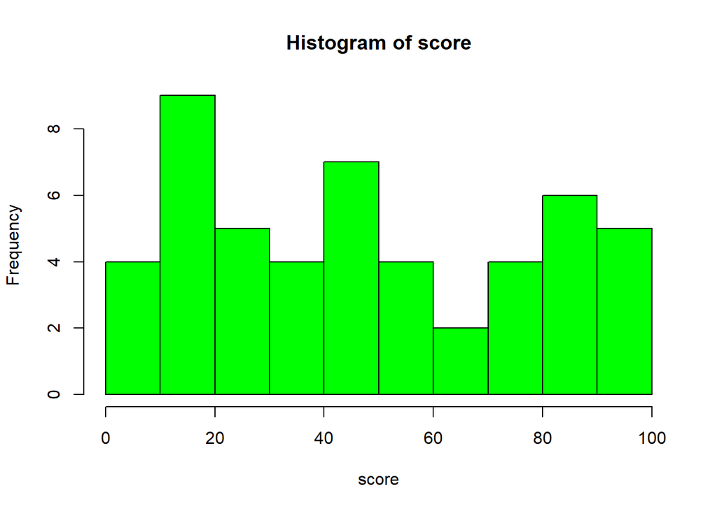

```r
score <- sample(1:100,50,replace = T)  #50名學生的英文成績
hist(score,
     freq = 10,                        #將區間以10為單位間隔
     col="green"                       #設定顏色為綠色
     )
```

## 莖葉圖

一種用圖形來表現數據(或稱資料)的方法，方便且容易畫的圖形，用來說明數據的分佈情形。

```r
score <- sample(1:100,50,replace = T)  #50名學生的英文成績
stem(score)                            #畫出莖葉圖
```

```
##
##   The decimal point is 1 digit(s) to the right of the |
##
##   0 | 13567779
##   1 | 3389
##   2 | 4789
##   3 | 677
##   4 | 1223568
##   5 | 244559
##   6 | 27
##   7 | 045678
##   8 | 123899
##   9 | 2399
```

利用stem()函式可畫出莖葉圖，左邊區隔開的為分數的十位數，佑邊為對應的個別各位數。

## 肩形圖(ogive)

肩形圖(ogive)是累積相對次數(cumulative relative frequency)的圖形表示。

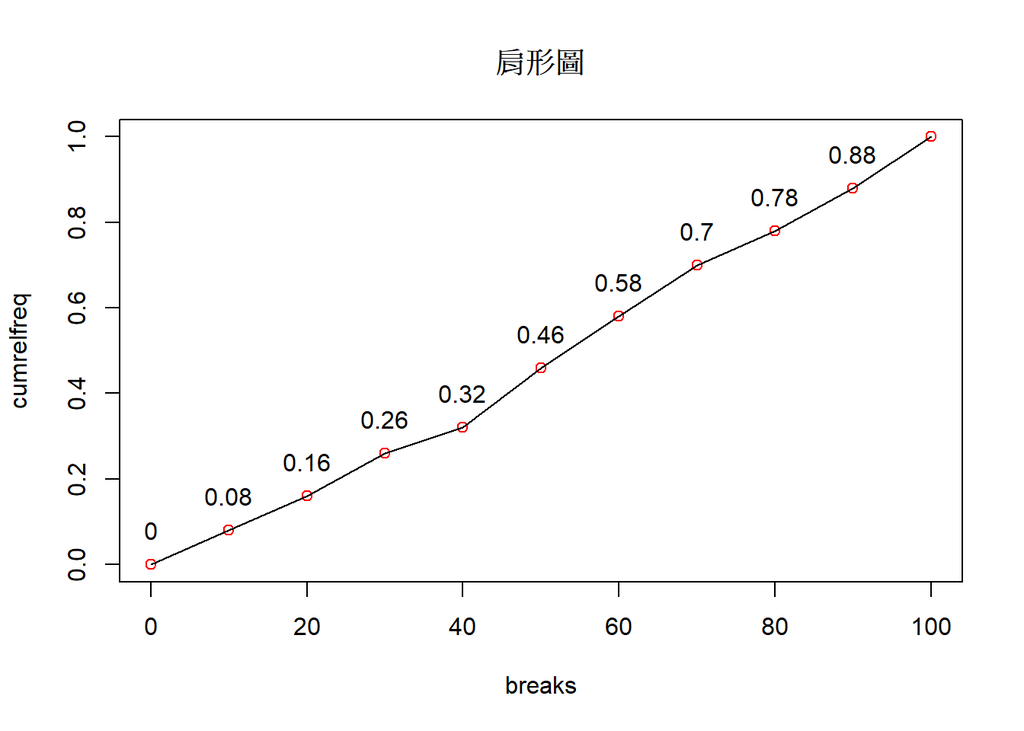

```r
score <- sample(1:100,50,replace = T)                #50名學生的英文成績
breaks=seq(0, 100, by=10)                            #設定X軸分數區間，以10分為一個間隔
score.cut <- cut(score, breaks, right=FALSE)         #將原始分數資料利用breaks區間分類
score.freq = table(score.cut)                        #將分類後資料轉成累積次數資料
cumfreq = c(0, cumsum(score.freq))                   #計算分別累積次數百分比
cumrelfreq = cumfreq / cumfreq[11]                   #計算累積相對次數百分比
options(digits=2)                                    #小數點取到第二位
plot(breaks, cumrelfreq, main="肩形圖", col="red")    #畫出肩形圖
lines(breaks, cumrelfreq)                            #將各點連結
text(breaks, cumrelfreq+0.08, cumrelfreq )           #標記各點累計機率
```

## 線圖(line chart)

時間序列通常以線圖(line chart) 來描述，它是對變數在不同時間點的值所繪的圖。

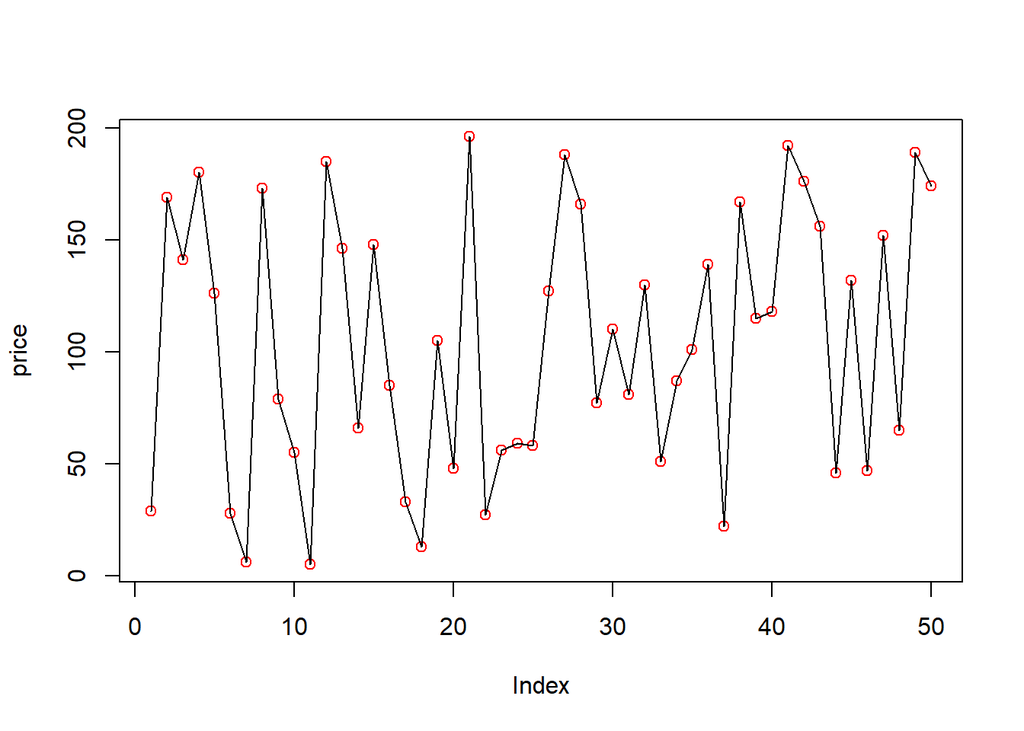

```r
price <- sample(1:200,50,replace = F)  #某上市股票其50週收盤價格
plot(price, col="red")                 #畫出每周所對應其收盤價格
lines(price)                           #連結各點
```

## 散佈圖(scatter diagram)

將兩區間變數分別對應到2個維度座標軸上(X,Y軸)，並觀察其對應是否有相關性，本次運用R語言內建資料庫，cars此筆數據共記載了兩筆數據，一為汽車速度，一為每次煞車到到靜止所需距離。

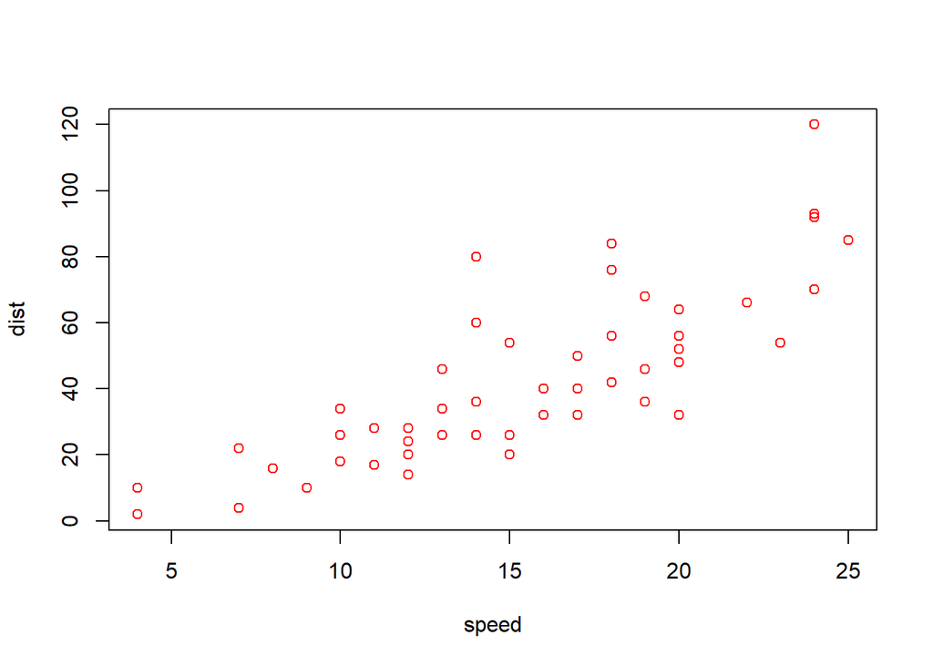

```r
plot(cars, col="red")                 #畫出速度與距離散布圖
```

由散布圖中可觀察出當汽車速度越快，所需要的煞車距離更大，透露出兩著變數間具有正向的線性關係。